# **Overview**

In this assignment, you will design an Entity-Relationship Diagram (ERD) to model the structure of a system of your choice. The ERD should reflect the logical design stage and include entities, relationships, attributes, primary and foreign keys, and data types. You are free to choose the type of system you want to model (e.g., an online store, a healthcare management system, a student course enrollment system), but the ERD must meet the minimum requirements listed below.

# **Minimum Requirements**

- Entities
  - Include at least 3 entities.
  - Each entity must have a minimum of 4 attributes, including the primary key.
  - Each entity must have a Primary Key (PK).
- Attributes
  - Use at least 3 different data types across all entities (e.g., INT, DECIMAL(p, s), FLOAT, CHAR(n), VARCHAR(n), TEXT, DATE, TIME, DATETIME, TIMESTAMP, BOOLEAN).
- Relationships
  - Establish relationships between entities with appropriate cardinality.
  - Include at least 2 foreign keys (FK) to represent these relationships.
  - Use Crow's Foot notation to represent relationships in your ERD.

# Choose a System to Model

Select a system that you are familiar with or interested in.

Examples include but are not limited to:

- Online Retail Store
- Hospital Management System
- Social Media Platform
- University Enrollment System
- Hotel Reservation System
- Library Management System
- Inventory Management System
- Any other system of your choice

# **Define Entities and Attributes**

- List all entities and their attributes.
- Assign data types to each attribute.
- Identify primary keys for each entity.
- Example:
  - Customers
    - CustomerID (INT) (PK)
    - FirstName (VARCHAR(50))
    - LastName (VARCHAR(50))
    - Email (VARCHAR(100))
  - Orders
    - OrderID (INT) (PK)
    - Customer ID (INT)
    - Ship Date (DATE)

# **Establish Relationships and Foreign Keys**

- Determine how entities are related.
- Define foreign keys to establish these relationships.
- Specify cardinality for each relationship.
- Example:
  - Relationship:
    - Customer places Order
  - Cardinality:
    - One-to-Many (One Customer can place many Orders)
  - Foreign Key connecting Order Entity with Customer Entity
    - Orders
      - CustomerID (INT) [FK]

# **Create the ERD**

Use Lucidchart to draw the ERD of your system. Use the included ERD template to draw:

- Entities Attributes listed inside entities *Data types
- Primary Keys (marked as PK)
- Foreign Keys (marked as FK)
- Relationships drawn as lines, using Crow's Foot notation to indicate cardinality

Example:

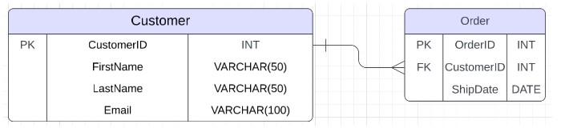

# **Deliverables**

A PDF document containing:

- An image of your ERD
- A link to the ERD on Lucidchart
- A brief description (1-2paragraphs) explaining:
  - Each entity and its role within the system.
  - The relationships between entities and the reasoning behind the cardinality chosen.
  - Any assumptions made during the design process. # **Resources**
- Lucidchart Tutorial Video showing general construction process, template usage, and getting sharable linkLinks to an external site.
- Lucidchart tutorial video showing template use and cardinality settingLinks to an external site.

To generate a report based on the provided `CREATE TABLE` statements for an **Online Retail Store** system, we need to analyze the entities, relationships, and design decisions. Below is an example report covering the required points.

# **Report: ERD for Online Retail Store System**

## **1. Introduction**

The **Online Retail Store System** ERD represents a database design for an e-commerce platform where customers can browse and purchase products. The system manages customer information, product details, orders, reviews, payments, shipping, and returns. The provided SQL statements reflect the structure of the entities in the system, along with their relationships.

## **2. Entities and Attributes**

### **Entities:**

#### **1. Customers**

- **Attributes**:
  - `CustomerID` (INT) (PK): The unique identifier for each customer.
  - `FirstName` (VARCHAR(50)): The customer's first name.
  - `LastName` (VARCHAR(50)): The customer's last name.
  - `Address` (VARCHAR(255)): The customer's physical address.
  - `Email` (VARCHAR(100)): The customer's email address.
  - `City` (VARCHAR(100)): The city of the customer.
  - `State` (VARCHAR(100)): The state of the customer.
  - `ZipCode` (VARCHAR(20)): The ZIP code of the customer.
  - `Country` (VARCHAR(100)): The country of the customer.
  - `PhoneNumber` (VARCHAR(15)): The customer's phone number.

#### **2. Categories**

- **Attributes**:
  - `CategoryID` (INT) (PK): The unique identifier for each category.
  - `CategoryName` (VARCHAR(100)): The name of the category.
  - `Description` (TEXT): The description of the category.
  - `CreatedDate` (DATETIME): The date when the category was created.
  - `IsActive` (BOOLEAN): Indicates if the category is active or not.

#### **3. Products**

- **Attributes**:
  - `ProductID` (INT) (PK): The unique identifier for each product.
  - `ProductName` (VARCHAR(100)): The name of the product.
  - `Description` (TEXT): The description of the product.
  - `Price` (DECIMAL): The price of the product.
  - `QuantityInStock` (INT): The quantity of the product in stock.
  - `CategoryID` (INT) (FK): The foreign key referencing **Categories**.
  - `ImageURL` (VARCHAR(255)): The URL of the product's image.

#### **4. Orders**

- **Attributes**:
  - `OrderID` (INT) (PK): The unique identifier for each order.
  - `OrderDate` (DATETIME): The date when the order was placed.
  - `OrderStatus` (VARCHAR(20)): The status of the order (e.g., pending, shipped).
  - `TotalAmount` (DECIMAL): The total amount of the order.
  - `CustomerID` (INT) (FK): The foreign key referencing **Customers**.
  - `ShippingAddressID` (INT): Reference to shipping address (can be a separate table).
  - `ReturnAddressID` (INT): Reference to return address (can be a separate table).

#### **5. OrderItems**

- **Attributes**:
  - `OrderItemID` (INT) (PK): The unique identifier for each order item.
  - `OrderID` (INT) (FK): The foreign key referencing **Orders**.
  - `ProductID` (INT) (FK): The foreign key referencing **Products**.
  - `Quantity` (INT): The quantity of the product ordered.
  - `Price` (DECIMAL): The price of the product at the time of the order.

#### **6. Payments**

- **Attributes**:
  - `PaymentID` (INT) (PK): The unique identifier for each payment.
  - `OrderID` (INT) (FK): The foreign key referencing **Orders**.
  - `PaymentMethod` (VARCHAR(50)): The method of payment (e.g., credit card, PayPal).
  - `PaymentDate` (DATETIME): The date and time of payment.
  - `Amount` (DECIMAL): The payment amount.

#### **7. Shipping**

- **Attributes**:
  - `ShippingID` (INT) (PK): The unique identifier for each shipping entry.
  - `OrderID` (INT) (FK): The foreign key referencing **Orders**.
  - `ShippingCarrier` (VARCHAR(100)): The carrier handling the shipment.
  - `TrackingNumber` (VARCHAR(100)): The tracking number for the shipment.
  - `EstimatedDeliveryDate` (DATE): The estimated delivery date.

#### **8. Returns**

- **Attributes**:
  - `ReturnID` (INT) (PK): The unique identifier for each return.
  - `OrderID` (INT) (FK): The foreign key referencing **Orders**.
  - `ReturnReason` (VARCHAR(255)): The reason for the return.
  - `ReturnDate` (DATE): The date the return was processed.
  - `ReturnStatus` (VARCHAR(50)): The status of the return (e.g., pending, completed).

#### **9. Reviews**

- **Attributes**:
  - `ReviewID` (INT) (PK): The unique identifier for each review.
  - `ProductID` (INT) (FK): The foreign key referencing **Products**.
  - `CustomerID` (INT) (FK): The foreign key referencing **Customers**.
  - `Rating` (INT): The rating given by the customer (typically 1-5 stars).
  - `Comment` (TEXT): The review comment.

## **3. Relationships Between Entities**

### **1. Customers and Orders** (One-to-Many)

- **Explanation**: A **Customer** can place multiple **Orders**, but each **Order** belongs to a single **Customer**.
- **Foreign Key**: `CustomerID` in **Orders** references `CustomerID` in **Customers**.

### **2. Orders and OrderItems** (One-to-Many)

- **Explanation**: An **Order** can have multiple **OrderItems**, but each **OrderItem** belongs to a single **Order**.
- **Foreign Key**: `OrderID` in **OrderItems** references `OrderID` in **Orders**.

### **3. Products and OrderItems** (One-to-Many)

- **Explanation**: A **Product** can be included in multiple **OrderItems**, but each **OrderItem** references a single **Product**.
- **Foreign Key**: `ProductID` in **OrderItems** references `ProductID` in **Products**.

### **4. Products and Reviews** (One-to-Many)

- **Explanation**: A **Product** can have multiple **Reviews**, but each **Review** is written for a single **Product**.
- **Foreign Key**: `ProductID` in **Reviews** references `ProductID` in **Products**.

### **5. Customers and Reviews** (One-to-Many)

- **Explanation**: A **Customer** can write multiple **Reviews**, but each **Review** is written by a single **Customer**.
- **Foreign Key**: `CustomerID` in **Reviews** references `CustomerID` in **Customers**.

## **4. ERD Diagram**

Below is the ERD model for the **Online Retail Store System**, visualized using **Crow's Foot Notation**.

```
mermaid
erDiagram
    CUSTOMERS {
        INT CustomerID PK
        VARCHAR FirstName
        VARCHAR LastName
        VARCHAR Email
        VARCHAR Address
        VARCHAR City
        VARCHAR State
        VARCHAR ZipCode
        VARCHAR Country
        VARCHAR PhoneNumber
    }

    CATEGORIES {
        INT CategoryID PK
        VARCHAR CategoryName
        TEXT Description
        DATETIME CreatedDate
        BOOLEAN IsActive
    }

    PRODUCTS {
        INT ProductID PK
        VARCHAR ProductName
        TEXT Description
        DECIMAL Price
        INT QuantityInStock
        INT CategoryID FK
        VARCHAR ImageURL
    }

    ORDERS {
        INT OrderID PK
        DATETIME OrderDate
        VARCHAR OrderStatus
        DECIMAL TotalAmount
        INT CustomerID FK
        INT ShippingAddressID
        INT ReturnAddressID
    }

    ORDERITEMS {
        INT OrderItemID PK
        INT OrderID FK
        INT ProductID FK
        INT Quantity
        DECIMAL Price
    }

    PAYMENTS {
        INT PaymentID PK
        INT OrderID FK
        VARCHAR PaymentMethod
        DATETIME PaymentDate
        DECIMAL Amount
    }

    SHIPPING {
        INT ShippingID PK
        INT OrderID FK
        VARCHAR ShippingCarrier
        VARCHAR TrackingNumber
        DATE EstimatedDeliveryDate
    }

    RETURNS {
        INT ReturnID PK
        INT OrderID FK
        VARCHAR ReturnReason
        DATE ReturnDate
        VARCHAR ReturnStatus
    }

    REVIEWS {
        INT ReviewID PK
        INT ProductID FK
        INT CustomerID FK
        INT Rating
        TEXT Comment
    }

    CUSTOMERS ||--o{ ORDERS : places
    ORDERS ||--|{ ORDERITEMS : contains
    PRODUCTS ||--|{ ORDERITEMS : includes
    PRODUCTS ||--o{ REVIEWS : has
    CUSTOMERS ||--o{ REVIEWS : writes
```

## **5. Assumptions and Design Decisions**

### Design Decisions:

- **OrderItems** table manages the many-to-many relationship between **Orders** and **Products**, which allows for a flexible order structure.
- **Shipping** and **Returns** are associated with **Orders**, providing support for logistics and post-order activities.

## **6. Conclusion**

The database design for the **Online Retail Store** system efficiently models the relationships between **Customers**, **Orders**, **Products**, **Categories**, **Reviews**, **Payments**, **Shipping**, and **Returns**. This structure allows for effective management of customer interactions, product management, order processing, payments, and logistics.

This concludes the report for the **Online Retail Store System** ERD.

# Choose a System to Model

Online Retail Store

# Define Entities and Attributes

List all entities and their attributes.

### 1. **CUSTOMERS**

- **CustomerID** (INT, PK): Unique identifier for each customer.
- **FirstName** (VARCHAR(50)): Customer's first name.
- **LastName** (VARCHAR(50)): Customer's last name.
- **Address** (VARCHAR(255)): Customer's full address.
- **Email** (VARCHAR(100)): Customer's email address.
- **City** (VARCHAR(100)): City of the customer.
- **State** (VARCHAR(100)): State of the customer.
- **ZipCode** (VARCHAR(20)): Postal code for the customer's address.
- **Country** (VARCHAR(100)): Customer's country of residence.
- **PhoneNumber** (VARCHAR(15)): Customer's contact phone number.

### 2. **CATEGORIES**

- **CategoryID** (INT, PK): Unique identifier for each product category.
- **CategoryName** (VARCHAR(100)): Name of the product category.
- **Description** (TEXT): Description of the product category.
- **CreatedDate** (DATETIME): Date and time the category was created (default: current timestamp).
- **IsActive** (BOOLEAN): Indicates if the category is currently active (default: TRUE).

### 3. **PRODUCTS**

- **ProductID** (INT, PK): Unique identifier for each product.
- **ProductName** (VARCHAR(100)): Name of the product.
- **Description** (TEXT): Detailed description of the product.
- **Price** (DECIMAL): Price of the product.
- **QuantityInStock** (INT): Current stock level of the product.
- **CategoryID** (INT, FK): Foreign key that references the `CATEGORIES(CategoryID)`.
- **ImageURL** (VARCHAR(255)): URL to an image of the product.

### 4. **ORDERS**

- **OrderID** (INT, PK): Unique identifier for each order.
- **OrderDate** (DATETIME): Date and time when the order was placed.
- **OrderStatus** (VARCHAR(20)): Status of the order (e.g., Pending, Shipped, Completed).
- **TotalAmount** (DECIMAL): Total amount for the order.
- **CustomerID** (INT, FK): Foreign key that references the `CUSTOMERS(CustomerID)`.
- **ShippingAddressID** (INT): Placeholder for shipping address (not defined as a foreign key in this design).
- **ReturnAddressID** (INT): Placeholder for return address (not defined as a foreign key in this design).

### 5. **ORDERITEMS**

- **OrderItemID** (INT, PK): Unique identifier for each item in an order.
- **OrderID** (INT, FK): Foreign key that references the `ORDERS(OrderID)`.
- **ProductID** (INT, FK): Foreign key that references the `PRODUCTS(ProductID)`.
- **Quantity** (INT): Number of units of the product ordered.
- **Price** (DECIMAL): Price of the product at the time of the order (snapshot of `PRODUCTS.Price`).

### 6. **PAYMENTS**

- **PaymentID** (INT, PK): Unique identifier for each payment transaction.
- **OrderID** (INT, FK): Foreign key that references the `ORDERS(OrderID)`.
- **PaymentMethod** (VARCHAR(50)): Payment method used (e.g., Credit Card, PayPal).
- **PaymentDate** (DATETIME): Date and time the payment was made.
- **Amount** (DECIMAL): Amount paid.

### 7. **SHIPPING**

- **ShippingID** (INT, PK): Unique identifier for each shipping record.
- **OrderID** (INT, FK): Foreign key that references the `ORDERS(OrderID)`.
- **ShippingCarrier** (VARCHAR(100)): Shipping carrier (e.g., FedEx, UPS).
- **TrackingNumber** (VARCHAR(100)): Tracking number provided by the carrier.
- **EstimatedDeliveryDate** (DATE): Estimated date of delivery.

### 8. **RETURNS**

- **ReturnID** (INT, PK): Unique identifier for each return transaction.
- **OrderID** (INT, FK): Foreign key that references the `ORDERS(OrderID)`.
- **ReturnReason** (VARCHAR(255)): Reason for the return.
- **ReturnDate** (DATE): Date the return was initiated.
- **ReturnStatus** (VARCHAR(50)): Status of the return (e.g., Approved, Rejected, Processing).

### 9. **REVIEWS**

- **ReviewID** (INT, PK): Unique identifier for each review.
- **ProductID** (INT, FK): Foreign key that references the `PRODUCTS(ProductID)`.
- **CustomerID** (INT, FK): Foreign key that references the `CUSTOMERS(CustomerID)`.
- **Rating** (INT): Rating provided by the customer (e.g., on a scale of 1 to 5).
- **Comment** (TEXT): Customer's review comment or feedback.

# Establish Relationships and Foreign Keys

Determine how entities are related.

# Define foreign keys to establish these relationships.

```
CREATE TABLE `CUSTOMERS` (
  `CustomerID` INT,
  `FirstName` VARCHAR(50),
  `LastName` VARCHAR(50),
  `Address` VARCHAR(255),
  `Email` VARCHAR(100),
  `City` VARCHAR(100),
  `State` VARCHAR(100),
  `ZipCode` VARCHAR(20),
  `Country` VARCHAR(100),
  `PhoneNumber` VARCHAR(15),
  PRIMARY KEY (`CustomerID`)
);

CREATE TABLE `CATEGORIES` (
  `CategoryID` INT,
  `CategoryName` VARCHAR(100),
  `Description` TEXT,
  `CreatedDate` DATETIME DEFAULT CURRENT_TIMESTAMP,
  `IsActive` BOOLEAN DEFAULT TRUE,
  PRIMARY KEY (`CategoryID`)
);

CREATE TABLE `PRODUCTS` (
  `ProductID` INT,
  `ProductName` VARCHAR(100),
  `Description` TEXT,
  `Price` DECIMAL(10, 2),
  `QuantityInStock` INT,
  `CategoryID` INT,
  `ImageURL` VARCHAR(255),
  PRIMARY KEY (`ProductID`),
  FOREIGN KEY (`CategoryID`) REFERENCES `CATEGORIES`(`CategoryID`)
);

CREATE TABLE `ORDERS` (
  `OrderID` INT,
  `OrderDate` DATETIME,
  `OrderStatus` VARCHAR(20),
  `TotalAmount` DECIMAL(10, 2),
  `CustomerID` INT,
  `ShippingAddressID` INT,
  `ReturnAddressID` INT,
  PRIMARY KEY (`OrderID`),
  FOREIGN KEY (`CustomerID`) REFERENCES `CUSTOMERS`(`CustomerID`)
);

CREATE TABLE `ORDERITEMS` (
  `OrderItemID` INT,
  `OrderID` INT,
  `ProductID` INT,
  `Quantity` INT,
  `Price` DECIMAL(10, 2),
  PRIMARY KEY (`OrderItemID`),
  FOREIGN KEY (`OrderID`) REFERENCES `ORDERS`(`OrderID`),
  FOREIGN KEY (`ProductID`) REFERENCES `PRODUCTS`(`ProductID`)
);

CREATE TABLE `PAYMENTS` (
  `PaymentID` INT,
  `OrderID` INT,
  `PaymentMethod` VARCHAR(50),
  `PaymentDate` DATETIME,
  `Amount` DECIMAL(10, 2),
  PRIMARY KEY (`PaymentID`),
  FOREIGN KEY (`OrderID`) REFERENCES `ORDERS`(`OrderID`)
);

CREATE TABLE `SHIPPING` (
  `ShippingID` INT,
  `OrderID` INT,
  `ShippingCarrier` VARCHAR(100),
  `TrackingNumber` VARCHAR(100),
  `EstimatedDeliveryDate` DATE,
  PRIMARY KEY (`ShippingID`),
  FOREIGN KEY (`OrderID`) REFERENCES `ORDERS`(`OrderID`)
);

CREATE TABLE `RETURNS` (
  `ReturnID` INT,
  `OrderID` INT,
  `ReturnReason` VARCHAR(255),
  `ReturnDate` DATE,
  `ReturnStatus` VARCHAR(50),
  PRIMARY KEY (`ReturnID`),
  FOREIGN KEY (`OrderID`) REFERENCES `ORDERS`(`OrderID`)
);

CREATE TABLE `REVIEWS` (
  `ReviewID` INT,
  `ProductID` INT,
  `CustomerID` INT,
  `Rating` INT,
  `Comment` TEXT,
  PRIMARY KEY (`ReviewID`),
  FOREIGN KEY (`CustomerID`) REFERENCES `CUSTOMERS`(`CustomerID`),
  FOREIGN KEY (`ProductID`) REFERENCES `PRODUCTS`(`ProductID`)
);
```

### Summary of Foreign Keys Defined:

1. **PRODUCTS**:
   - `CategoryID` references `CATEGORIES(CategoryID)`: Establishes a relationship between products and categories.
2. **ORDERS**:
   - `CustomerID` references `CUSTOMERS(CustomerID)`: Links an order to the customer who placed it.
3. **ORDERITEMS**:
   - `OrderID` references `ORDERS(OrderID)`: Links each order item to the order it belongs to.
   - `ProductID` references `PRODUCTS(ProductID)`: Links each order item to the product being purchased.
4. **PAYMENTS**:
   - `OrderID` references `ORDERS(OrderID)`: Links a payment to the corresponding order.
5. **SHIPPING**:
   - `OrderID` references `ORDERS(OrderID)`: Links shipping details to the corresponding order.
6. **RETURNS**:
   - `OrderID` references `ORDERS(OrderID)`: Links return information to the corresponding order.
7. **REVIEWS**:
   - `CustomerID` references `CUSTOMERS(CustomerID)`: Links a review to the customer who wrote it.
   - `ProductID` references `PRODUCTS(ProductID)`: Links a review to the product being reviewed.

# Specify cardinality for each relationship.

### Cardinality Notation:

Here’s how you might represent this using notation in an ER diagram or SQL documentation:

- **One-to-One (1:1)**: Each entity in the relationship will have at most one related entity.
- **One-to-Many (1:N)**: One entity can be associated with multiple entities on the "many" side, but each entity on the "many" side is associated with exactly one entity on the "one" side.

# Create the ERD

Use Lucidchart to draw the ERD of your system. Use the included ERD template to draw:

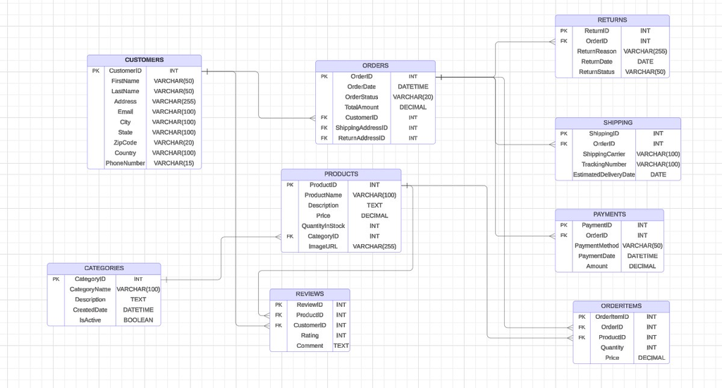

# A link to the ERD on Lucidchart

1:Lucidchart Link:

https://lucid.app/lucidchart/6183e454-b841-4ead-b332-a5388b958a1d/edit?viewport_loc=-2198%2C-1443%2C3508%2C1520%2Cephget3akdC8&invitationId=inv_6ab7bd62-3fb1-4b94-9171-9cf930dea79a

2:Test ERD BY SQL Fiddle:

https://sqlfiddle.com/mysql/online-compiler?id=a20c9bbb-2b9c-4e8f-a271-2ac2ce7e04a9

# A brief description (1-2paragraphs) explaining

Each entity and its role within the system.

### 2. **CATEGORIES**

- **Role**: Represents different categories of products.
- **Attributes**:
  - `CategoryID`: Unique identifier for each category.
  - `CategoryName`: Name of the product category (e.g., Electronics, Apparel).
  - `Description`: Additional details about the category.
  - `CreatedDate`: Date when the category was created.
  - `IsActive`: Whether the category is currently active.
- **Role within the system**: Organizes products into categories, making it easier for customers to browse products.

### 3. **PRODUCTS**

- **Role**: Represents individual products available for purchase.
- **Attributes**:
  - `ProductID`: Unique identifier for each product.
  - `ProductName`: Name of the product.
  - `Description`: Description of the product.
  - `Price`: Cost of the product.
  - `QuantityInStock`: The quantity available in stock.
  - `CategoryID`: Links the product to a specific category.
  - `ImageURL`: URL of the product image for displaying online.
- **Role within the system**: Tracks inventory, product details, and links to categories. It's also linked to orders and reviews.

### 4. **ORDERS**

- **Role**: Represents individual customer purchases.
- **Attributes**:
  - `OrderID`: Unique identifier for each order.
  - `OrderDate`: Date when the order was placed.
  - `OrderStatus`: Current status of the order (e.g., Processing, Shipped, Delivered).
  - `TotalAmount`: Total cost of the order.
  - `CustomerID`: Links the order to the customer who made it.
  - `ShippingAddressID`, `ReturnAddressID`: References to addresses related to shipping or returns.
- **Role within the system**: Tracks customer purchases and is connected to order items, shipping details, and payments.

### 5. **ORDERITEMS**

- **Role**: Represents individual items within a customer’s order.
- **Attributes**:
  - `OrderItemID`: Unique identifier for each order item.
  - `OrderID`: Links the item to the corresponding order.
  - `ProductID`: Links the item to the specific product being ordered.
  - `Quantity`: Number of units of the product in the order.
  - `Price`: Price of the product at the time of the order.
- **Role within the system**: Breaks down the order into individual products and quantities. Each item in an order is stored separately in this entity.

### 6. **PAYMENTS**

- **Role**: Represents payment information for each order.
- **Attributes**:
  - `PaymentID`: Unique identifier for each payment.
  - `OrderID`: Links the payment to the corresponding order.
  - `PaymentMethod`: The payment method used (e.g., Credit Card, PayPal).
  - `PaymentDate`: Date when the payment was made.
  - `Amount`: Total amount paid.
- **Role within the system**: Tracks how and when payments for orders are made. Linked directly to orders.

### 7. **SHIPPING**

- **Role**: Represents the shipping details for each order.
- **Attributes**:
  - `ShippingID`: Unique identifier for each shipping event.
  - `OrderID`: Links the shipping to the corresponding order.
  - `ShippingCarrier`: Carrier responsible for delivering the order (e.g., FedEx, UPS).
  - `TrackingNumber`: Tracking number for the shipment.
  - `EstimatedDeliveryDate`: The estimated date of delivery for the order.
- **Role within the system**: Tracks shipment details for each order, including tracking information and delivery estimates.

### 8. **RETURNS**

- **Role**: Represents return events for orders.
- **Attributes**:
  - `ReturnID`: Unique identifier for each return.
  - `OrderID`: Links the return to the corresponding order.
  - `ReturnReason`: The reason for returning the order.
  - `ReturnDate`: Date when the return was initiated.
  - `ReturnStatus`: Current status of the return (e.g., Pending, Completed).
- **Role within the system**: Tracks return events for orders, including reasons and status of the return.

### 9. **REVIEWS**

- **Role**: Represents customer reviews for products.
- **Attributes**:
  - `ReviewID`: Unique identifier for each review.
  - `ProductID`: Links the review to the product being reviewed.
  - `CustomerID`: Links the review to the customer who wrote it.
  - `Rating`: Numerical rating given to the product (e.g., 1-5 stars).
  - `Comment`: Additional comments about the product.
- **Role within the system**: Stores customer feedback and ratings for products, which can help other customers make informed purchase decisions.

### Entity Roles in Summary:

- **Customers** are at the core of the system, as they place orders, make payments, and write reviews.
- **Products** and **Categories** define what is available for purchase and help organize the inventory.
- **Orders** and **OrderItems** track what customers purchase, while **Payments**, **Shipping**, and **Returns** manage order logistics.
- **Reviews** provide feedback about products, closing the loop between customer purchases and product satisfaction.

# The relationships between entities and the reasoning behind the cardinality chosen.

### 1. **CUSTOMERS and ORDERS**

- **Relationship**: A customer can place multiple orders, but each order is placed by only one customer.
- **Cardinality**: **One-to-Many (1:N)**
  - **Reasoning**: A single customer (1) can make many orders (N), but each order is linked to one and only one customer.
  - **Foreign Key**: `CustomerID` in the `ORDERS` table references `CustomerID` in the `CUSTOMERS` table.

### 2. **ORDERS and ORDERITEMS**

- **Relationship**: An order can contain multiple products (items), and each product is part of one specific order.
- **Cardinality**: **One-to-Many (1:N)**
  - **Reasoning**: An order (1) typically contains multiple products (N), but each order item belongs to one specific order.
  - **Foreign Key**: `OrderID` in the `ORDERITEMS` table references `OrderID` in the `ORDERS` table.

### 3. **ORDERITEMS and PRODUCTS**

- **Relationship**: A product can appear in multiple order items (since different customers can buy the same product), and each order item is associated with one product.
- **Cardinality**: **Many-to-One (N:1)**
  - **Reasoning**: Multiple order items (N) can refer to the same product (1) because the same product can be ordered by different customers in different orders.
  - **Foreign Key**: `ProductID` in the `ORDERITEMS` table references `ProductID` in the `PRODUCTS` table.

### 4. **CATEGORIES and PRODUCTS**

- **Relationship**: A category can have multiple products, but each product belongs to one specific category.
- **Cardinality**: **One-to-Many (1:N)**
  - **Reasoning**: A single category (1) can contain many products (N), but each product belongs to only one category.
  - **Foreign Key**: `CategoryID` in the `PRODUCTS` table references `CategoryID` in the `CATEGORIES` table.

### 5. **ORDERS and PAYMENTS**

- **Relationship**: An order can have multiple payments (if partial payments are allowed), but each payment is associated with one order.
- **Cardinality**: **One-to-Many (1:N)**
  - **Reasoning**: One order (1) might have multiple payments (N), such as in cases of partial payments or installment plans, but each payment relates to only one order.
  - **Foreign Key**: `OrderID` in the `PAYMENTS` table references `OrderID` in the `ORDERS` table.

### 7. **ORDERS and RETURNS**

- **Relationship**: An order can have multiple return records (if multiple returns are allowed), but each return is associated with one order.
- **Cardinality**: **One-to-Many (1:N)**
  - **Reasoning**: One order (1) can be returned partially or fully, so there can be multiple return events (N) for an order. However, each return corresponds to one specific order.
  - **Foreign Key**: `OrderID` in the `RETURNS` table references `OrderID` in the `ORDERS` table.

### 8. **PRODUCTS and REVIEWS**

- **Relationship**: A product can have multiple customer reviews, but each review is for one specific product.
- **Cardinality**: **One-to-Many (1:N)**
  - **Reasoning**: A single product (1) can receive many reviews (N), but each review is for only one product.
  - **Foreign Key**: `ProductID` in the `REVIEWS` table references `ProductID` in the `PRODUCTS` table.

### 9. **CUSTOMERS and REVIEWS**

- **Relationship**: A customer can write multiple reviews, but each review is written by only one customer.
- **Cardinality**: **One-to-Many (1:N)**
  - **Reasoning**: A customer (1) can write many reviews (N), but each review belongs to only one customer.
  - **Foreign Key**: `CustomerID` in the `REVIEWS` table references `CustomerID` in the `CUSTOMERS` table.

### Reasoning Behind Cardinality Choices:

- **Customer behavior**: Customers typically place multiple orders over time, leading to a 1:N relationship with orders. Similarly, customers write multiple reviews for different products, establishing a 1:N relationship.
- **Order structure**: An order can contain multiple items (products), leading to 1:N relationships between orders and order items. Payments are typically linked to orders in a 1:N manner if partial or multiple payments are allowed.
- **Product reviews**: Products often receive multiple reviews, establishing a 1:N relationship between products and reviews. Customers can review different products, leading to another 1:N relationship.
- **Inventory management**: Products are categorized to make browsing easier, and each category can contain many products, but each product belongs to a specific category, leading to a 1:N relationship.

# Any assumptions made during the design process.

### 1. **Customers place multiple orders**

- **Assumption**: A single customer can place many orders over time, but each order belongs to one and only one customer. This assumption is typical for e-commerce platforms where customers may return to make multiple purchases.
- **Impact**: This led to the **1:N relationship** between `CUSTOMERS` and `ORDERS`.

### 2. **Each order contains multiple items**

- **Assumption**: Orders will often contain multiple products, with each product having a specific quantity. This reflects typical scenarios where customers purchase multiple items in a single transaction.
- **Impact**: This drove the **1:N relationship** between `ORDERS` and `ORDERITEMS`.

### 3. **Products belong to only one category**

- **Assumption**: Each product is assigned to only one category. It assumes that products won’t belong to multiple categories at once, simplifying category management.
- **Impact**: This led to a **1:N relationship** between `CATEGORIES` and `PRODUCTS`.

### 5. **One payment method per payment**

- **Assumption**: Each payment is made using a single payment method. If an order allows for multiple payments (e.g., in installments or partial payments), each payment is recorded separately, with its own payment method.
- **Impact**: This resulted in a **1:N relationship** between `ORDERS` and `PAYMENTS`, allowing flexibility in handling multiple payments for one order.

### 6. **Each order can have multiple returns**

- **Assumption**: Customers may return one or more items from an order, leading to multiple return records for a single order (e.g., a customer returns items in different batches).
- **Impact**: This assumption led to the **1:N relationship** between `ORDERS` and `RETURNS`.

### 7. **Each product can receive multiple reviews**

- **Assumption**: Products typically receive reviews from multiple customers. However, each review is linked to a specific customer and product.
- **Impact**: This formed the **1:N relationship** between `PRODUCTS` and `REVIEWS`.

### 8. **Customers can review multiple products**

- **Assumption**: A customer may review different products. Each review is uniquely tied to one customer and one product, and a customer can submit multiple reviews for different products.
- **Impact**: This created the **1:N relationship** between `CUSTOMERS` and `REVIEWS`.

### 9. **Product stock is managed per product**

- **Assumption**: Each product’s stock is managed individually. There’s no need for a separate inventory system outside of the `PRODUCTS` table for tracking stock quantities.
- **Impact**: The `PRODUCTS` table includes a `QuantityInStock` field, assuming that stock levels are managed at the product level.

### 10. **Orders are distinct from customers’ shipping and return addresses**

- **Assumption**: The `ShippingAddressID` and `ReturnAddressID` fields in the `ORDERS` table point to separate potential address records (not defined in the current design), assuming that customers can choose different addresses for shipping and returns.
- **Impact**: This allows flexibility for customers to use different addresses for different purposes.

### 11. **No need for soft deletes or historical records**

- **Assumption**: The design does not account for historical data retention (e.g., soft deletes or archiving old records). It assumes that once a record is deleted or updated, the previous state is not retained.
- **Impact**: The design focuses on a straightforward relational model without audit trails or historical tracking.

### 12. **All data inputs are valid**

- **Assumption**: The design assumes data validation and integrity will be handled at the application level (outside the database). For example, it assumes that product prices will not be negative and that the number of items ordered will always be positive.
- **Impact**: This assumption simplifies the schema by excluding constraints like CHECK constraints for non-negative prices.

### Potential Modifications for Further Assumptions:

1. **Address management**: If the system needs to support multiple addresses per customer (billing, shipping, etc.), a separate `ADDRESSES` table might be introduced.
2. **Multi-category products**: If products can belong to multiple categories, a junction table (e.g., `PRODUCT_CATEGORY`) would need to be introduced to support a many-to-many relationship.
3. **Soft Deletes**: For audit and traceability purposes, soft delete mechanisms (e.g., `IsDeleted` flag) could be introduced to prevent physical deletion of important records.
4. **Product variants**: If the system needs to manage product variants (e.g., size, color), an additional `PRODUCT_VARIANTS` table might be required.

```python
import sqlite3

# Create a database in memory (for testing)
conn = sqlite3.connect('/content/online_retail_store.db')
cursor = conn.cursor()

# Step 1: Create Tables
def create_tables():
    cursor.execute('''
    CREATE TABLE IF NOT EXISTS CUSTOMERS (
        CustomerID INTEGER PRIMARY KEY,
        FirstName TEXT,
        LastName TEXT,
        Email TEXT,
        Address TEXT,
        City TEXT,
        State TEXT,
        ZipCode TEXT,
        Country TEXT,
        PhoneNumber TEXT
    );
    ''')

    cursor.execute('''
    CREATE TABLE IF NOT EXISTS CATEGORIES (
        CategoryID INTEGER PRIMARY KEY,
        CategoryName TEXT,
        Description TEXT,
        CreatedDate TEXT,
        IsActive BOOLEAN
    );
    ''')

    cursor.execute('''
    CREATE TABLE IF NOT EXISTS PRODUCTS (
        ProductID INTEGER PRIMARY KEY,
        ProductName TEXT,
        Description TEXT,
        Price REAL,
        QuantityInStock INTEGER,
        CategoryID INTEGER,
        ImageURL TEXT,
        FOREIGN KEY(CategoryID) REFERENCES CATEGORIES(CategoryID)
    );
    ''')

    cursor.execute('''
    CREATE TABLE IF NOT EXISTS ORDERS (
        OrderID INTEGER PRIMARY KEY,
        OrderDate TEXT,
        OrderStatus TEXT,
        TotalAmount REAL,
        CustomerID INTEGER,
        ShippingAddressID INTEGER,
        ReturnAddressID INTEGER,
        FOREIGN KEY(CustomerID) REFERENCES CUSTOMERS(CustomerID)
    );
    ''')

    cursor.execute('''
    CREATE TABLE IF NOT EXISTS ORDERITEMS (
        OrderItemID INTEGER PRIMARY KEY,
        OrderID INTEGER,
        ProductID INTEGER,
        Quantity INTEGER,
        Price REAL,
        FOREIGN KEY(OrderID) REFERENCES ORDERS(OrderID),
        FOREIGN KEY(ProductID) REFERENCES PRODUCTS(ProductID)
    );
    ''')

    cursor.execute('''
    CREATE TABLE IF NOT EXISTS PAYMENTS (
        PaymentID INTEGER PRIMARY KEY,
        OrderID INTEGER,
        PaymentMethod TEXT,
        PaymentDate TEXT,
        Amount REAL,
        FOREIGN KEY(OrderID) REFERENCES ORDERS(OrderID)
    );
    ''')

    cursor.execute('''
    CREATE TABLE IF NOT EXISTS SHIPPING (
        ShippingID INTEGER PRIMARY KEY,
        OrderID INTEGER,
        ShippingCarrier TEXT,
        TrackingNumber TEXT,
        EstimatedDeliveryDate TEXT,
        FOREIGN KEY(OrderID) REFERENCES ORDERS(OrderID)
    );
    ''')

    cursor.execute('''
    CREATE TABLE IF NOT EXISTS RETURNS (
        ReturnID INTEGER PRIMARY KEY,
        OrderID INTEGER,
        ReturnReason TEXT,
        ReturnDate TEXT,
        ReturnStatus TEXT,
        FOREIGN KEY(OrderID) REFERENCES ORDERS(OrderID)
    );
    ''')

    cursor.execute('''
    CREATE TABLE IF NOT EXISTS REVIEWS (
        ReviewID INTEGER PRIMARY KEY,
        ProductID INTEGER,
        CustomerID INTEGER,
        Rating INTEGER,
        Comment TEXT,
        FOREIGN KEY(ProductID) REFERENCES PRODUCTS(ProductID),
        FOREIGN KEY(CustomerID) REFERENCES CUSTOMERS(CustomerID)
    );
    ''')

# Step 2: Insert Data
def insert_sample_data():
    # Insert customers
    cursor.execute("INSERT INTO CUSTOMERS (FirstName, LastName, Email, Address, City, State, ZipCode, Country, PhoneNumber) VALUES ('John', 'Doe', 'john.doe@example.com', '123 Elm St', 'Some City', 'Some State', '12345', 'USA', '1234567890')")
    cursor.execute("INSERT INTO CUSTOMERS (FirstName, LastName, Email, Address, City, State, ZipCode, Country, PhoneNumber) VALUES ('Jane', 'Smith', 'jane.smith@example.com', '456 Oak St', 'Another City', 'Another State', '67890', 'USA', '0987654321')")

    # Insert categories
    cursor.execute("INSERT INTO CATEGORIES (CategoryName, Description, CreatedDate, IsActive) VALUES ('Electronics', 'Devices and gadgets', '2024-10-09', 1)")
    cursor.execute("INSERT INTO CATEGORIES (CategoryName, Description, CreatedDate, IsActive) VALUES ('Clothing', 'Apparel and fashion', '2024-10-09', 1)")

    # Insert products
    cursor.execute("INSERT INTO PRODUCTS (ProductName, Description, Price, QuantityInStock, CategoryID, ImageURL) VALUES ('Smartphone', 'Latest model smartphone', 699.99, 50, 1, 'http://example.com/smartphone.jpg')")
    cursor.execute("INSERT INTO PRODUCTS (ProductName, Description, Price, QuantityInStock, CategoryID, ImageURL) VALUES ('T-Shirt', 'Cotton t-shirt in various colors', 19.99, 100, 2, 'http://example.com/tshirt.jpg')")

    # Insert an order
    cursor.execute("INSERT INTO ORDERS (OrderDate, OrderStatus, TotalAmount, CustomerID, ShippingAddressID, ReturnAddressID) VALUES ('2024-10-09', 'Shipped', 719.98, 1, 1, 1)")

    # Insert order items
    cursor.execute("INSERT INTO ORDERITEMS (OrderID, ProductID, Quantity, Price) VALUES (1, 1, 1, 699.99)")
    cursor.execute("INSERT INTO ORDERITEMS (OrderID, ProductID, Quantity, Price) VALUES (1, 2, 1, 19.99)")

    # Insert payment
    cursor.execute("INSERT INTO PAYMENTS (OrderID, PaymentMethod, PaymentDate, Amount) VALUES (1, 'Credit Card', '2024-10-09', 719.98)")

    # Insert shipping
    cursor.execute("INSERT INTO SHIPPING (OrderID, ShippingCarrier, TrackingNumber, EstimatedDeliveryDate) VALUES (1, 'FedEx', '123456789', '2024-10-12')")

    # Insert return
    cursor.execute("INSERT INTO RETURNS (OrderID, ReturnReason, ReturnDate, ReturnStatus) VALUES (1, 'Defective item', '2024-10-10', 'Pending')")

    # Insert review
    cursor.execute("INSERT INTO REVIEWS (ProductID, CustomerID, Rating, Comment) VALUES (1, 1, 5, 'Great product, highly recommended!')")

# Step 3: Query Data
def query_data():
    cursor.execute("SELECT * FROM CUSTOMERS")
    customers = cursor.fetchall()
    print("Customers:")
    for row in customers:
        print(row)

    cursor.execute("SELECT * FROM PRODUCTS")
    products = cursor.fetchall()
    print("\nProducts:")
    for row in products:
        print(row)

    cursor.execute("SELECT * FROM ORDERS")
    orders = cursor.fetchall()
    print("\nOrders:")
    for row in orders:
        print(row)

# Create tables, insert data, and query data
create_tables()
insert_sample_data()
query_data()

# Commit and close
conn.commit()
conn.close()
```

```
Customers:
(1, 'John', 'Doe', 'john.doe@example.com', '123 Elm St', 'Some City', 'Some State', '12345', 'USA', '1234567890')
(2, 'Jane', 'Smith', 'jane.smith@example.com', '456 Oak St', 'Another City', 'Another State', '67890', 'USA', '0987654321')

Products:
(1, 'Smartphone', 'Latest model smartphone', 699.99, 50, 1, 'http://example.com/smartphone.jpg')
(2, 'T-Shirt', 'Cotton t-shirt in various colors', 19.99, 100, 2, 'http://example.com/tshirt.jpg')

Orders:
(1, '2024-10-09', 'Shipped', 719.98, 1, 1, 1)
```

```python
!apt-get install graphviz
!pip install graphviz
```

```
Reading package lists... Done
Building dependency tree... Done
Reading state information... Done
graphviz is already the newest version (2.42.2-6ubuntu0.1).
0 upgraded, 0 newly installed, 0 to remove and 49 not upgraded.
```

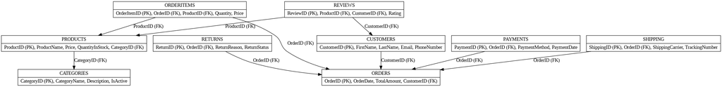

```python
import graphviz
from IPython.display import Image

# Create the ERD using Graphviz
erd_dot = """
digraph ERD {
    node [shape=record];

    CUSTOMERS [label="{CUSTOMERS|CustomerID (PK), FirstName, LastName, Email, PhoneNumber}"];
    CATEGORIES [label="{CATEGORIES|CategoryID (PK), CategoryName, Description, IsActive}"];
    PRODUCTS [label="{PRODUCTS|ProductID (PK), ProductName, Price, QuantityInStock, CategoryID (FK)}"];
    ORDERS [label="{ORDERS|OrderID (PK), OrderDate, TotalAmount, CustomerID (FK)}"];
    ORDERITEMS [label="{ORDERITEMS|OrderItemID (PK), OrderID (FK), ProductID (FK), Quantity, Price}"];
    PAYMENTS [label="{PAYMENTS|PaymentID (PK), OrderID (FK), PaymentMethod, PaymentDate}"];
    SHIPPING [label="{SHIPPING|ShippingID (PK), OrderID (FK), ShippingCarrier, TrackingNumber}"];
    RETURNS [label="{RETURNS|ReturnID (PK), OrderID (FK), ReturnReason, ReturnStatus}"];
    REVIEWS [label="{REVIEWS|ReviewID (PK), ProductID (FK), CustomerID (FK), Rating}"];

    CUSTOMERS -> ORDERS [label="CustomerID (FK)"];
    PRODUCTS -> CATEGORIES [label="CategoryID (FK)"];
    ORDERITEMS -> ORDERS [label="OrderID (FK)"];
    ORDERITEMS -> PRODUCTS [label="ProductID (FK)"];
    PAYMENTS -> ORDERS [label="OrderID (FK)"];
    SHIPPING -> ORDERS [label="OrderID (FK)"];
    RETURNS -> ORDERS [label="OrderID (FK)"];
    REVIEWS -> PRODUCTS [label="ProductID (FK)"];
    REVIEWS -> CUSTOMERS [label="CustomerID (FK)"];
}
"""

# Create the graph
erd = graphviz.Source(erd_dot)

# Render the ERD
erd.render("erd_graph", format="png")

# Display the ERD
Image(filename='erd_graph.png')
```

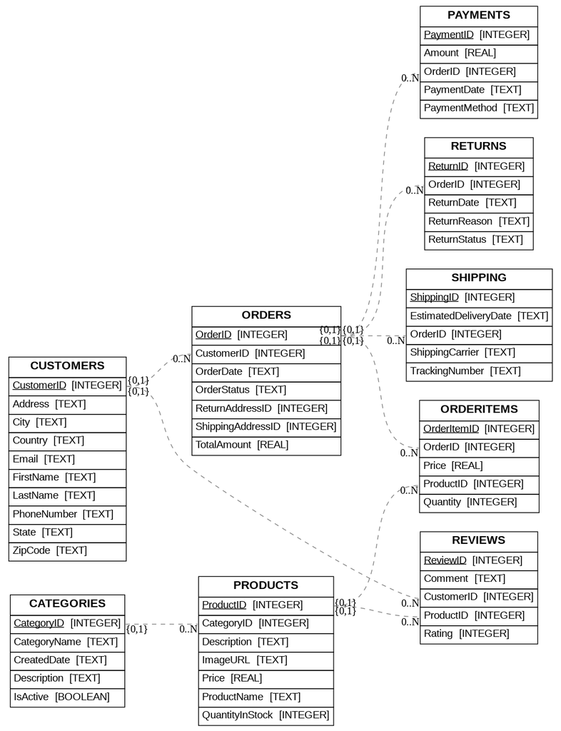

```python
# Import eralchemy for ERD generation
from eralchemy import render_er

# Use render_er to generate the ERD from the SQLite database
render_er('sqlite:///online_retail_store.db', 'online_retail_store_erd.png')

# Display the generated ERD image in Colab
from IPython.display import Image
Image('online_retail_store_erd.png')
```

# Creat database

```python
import sqlite3

# Connect to the SQLite database
conn = sqlite3.connect('/mnt/data/store.db')
cursor = conn.cursor()

# List of tables to delete data from
tables = ['CUSTOMERS', 'CATEGORIES', 'PRODUCTS', 'ORDERS', 'ORDERITEMS', 'PAYMENTS', 'SHIPPING', 'RETURNS', 'REVIEWS']

# Execute DELETE statements for all tables
for table in tables:
    cursor.execute(f"DELETE FROM {table}")
    print(f"All data removed from {table}.")

# Commit changes and close the connection
conn.commit()
conn.close()
```

[output not shown]

```python
import sqlite3

# Connect to SQLite database (in-memory database for testing)
conn = sqlite3.connect(':memory:')
cursor = conn.cursor()

# SQL script with table creation, insert data, and queries
sql_script = """
CREATE TABLE `CUSTOMERS` (
  `CustomerID` INT,
  `FirstName` VARCHAR(50),
  `LastName` VARCHAR(50),
  `Address` VARCHAR(255),
  `Email` VARCHAR(100),
  `City` VARCHAR(100),
  `State` VARCHAR(100),
  `ZipCode` VARCHAR(20),
  `Country` VARCHAR(100),
  `PhoneNumber` VARCHAR(15),
  PRIMARY KEY (`CustomerID`)
);

CREATE TABLE `CATEGORIES` (
 `CategoryID` INT,
  `CategoryName` VARCHAR(100),
  `Description` TEXT,
  `CreatedDate` DATETIME DEFAULT CURRENT_TIMESTAMP,
  `IsActive` BOOLEAN DEFAULT TRUE,
  PRIMARY KEY (`CategoryID`)
);

CREATE TABLE `PRODUCTS` (
  `ProductID` INT,
  `ProductName` VARCHAR(100),
  `Description` TEXT,
  `Price` DECIMAL,
  `QuantityInStock` INT,
  `CategoryID` INT,
  `ImageURL` VARCHAR(255),
  PRIMARY KEY (`ProductID`),
  FOREIGN KEY (`CategoryID`) REFERENCES `CATEGORIES`(`CategoryID`)
);

CREATE TABLE `ORDERS` (
  `OrderID` INT,
  `OrderDate` DATETIME,
  `OrderStatus` VARCHAR(20),
  `TotalAmount` DECIMAL,
  `CustomerID` INT,
  `ShippingAddressID` INT,
  `ReturnAddressID` INT,
  PRIMARY KEY (`OrderID`),
  FOREIGN KEY (`CustomerID`) REFERENCES `CUSTOMERS`(`CustomerID`)
);

CREATE TABLE `ORDERITEMS` (
  `OrderItemID` INT,
  `OrderID` INT,
  `ProductID` INT,
  `Quantity` INT,
  `Price` DECIMAL,
  PRIMARY KEY (`OrderItemID`),
  FOREIGN KEY (`OrderID`) REFERENCES `ORDERS`(`OrderID`),
  FOREIGN KEY (`ProductID`) REFERENCES `PRODUCTS`(`ProductID`)
);

CREATE TABLE `PAYMENTS` (
  `PaymentID` INT,
  `OrderID` INT,
  `PaymentMethod` VARCHAR(50),
  `PaymentDate` DATETIME,
  `Amount` DECIMAL,
  PRIMARY KEY (`PaymentID`),
  FOREIGN KEY (`OrderID`) REFERENCES `ORDERS`(`OrderID`)
);

CREATE TABLE `SHIPPING` (
  `ShippingID` INT,
  `OrderID` INT,
  `ShippingCarrier` VARCHAR(100),
  `TrackingNumber` VARCHAR(100),
  `EstimatedDeliveryDate` DATE,
  PRIMARY KEY (`ShippingID`),
  FOREIGN KEY (`OrderID`) REFERENCES `ORDERS`(`OrderID`)
);

CREATE TABLE `RETURNS` (
  `ReturnID` INT,
  `OrderID` INT,
  `ReturnReason` VARCHAR(255),
  `ReturnDate` DATE,
  `ReturnStatus` VARCHAR(50),
  PRIMARY KEY (`ReturnID`),
  FOREIGN KEY (`OrderID`) REFERENCES `ORDERS`(`OrderID`)
);

CREATE TABLE `REVIEWS` (
  `ReviewID` INT,
  `ProductID` INT,
  `CustomerID` INT,
  `Rating` INT,
  `Comment` TEXT,
  PRIMARY KEY (`ReviewID`),
  FOREIGN KEY (`CustomerID`) REFERENCES `CUSTOMERS`(`CustomerID`),
  FOREIGN KEY (`ProductID`) REFERENCES `PRODUCTS`(`ProductID`)
);

-- Insert Data into CUSTOMERS Table:
INSERT INTO `CUSTOMERS` (`CustomerID`, `FirstName`, `LastName`, `Address`, `Email`, `City`, `State`, `ZipCode`, `Country`, `PhoneNumber`)
VALUES
(1, 'John', 'Doe', '123 Elm St', 'john.doe@example.com', 'Fairfax', 'VA', '22030', 'USA', '555-1234'),
(2, 'Jane', 'Smith', '456 Oak St', 'jane.smith@example.com', 'Alexandria', 'VA', '22304', 'USA', '555-5678'),
(3, 'Robert', 'Johnson', '789 Pine St', 'robert.johnson@example.com', 'Arlington', 'VA', '22201', 'USA', '555-8765'),
(4, 'Emily', 'Davis', '321 Maple St', 'emily.davis@example.com', 'Washington', 'DC', '20001', 'USA', '555-4321'),
(5, 'Michael', 'Miller', '654 Birch St', 'michael.miller@example.com', 'Fairfax', 'VA', '22031', 'USA', '555-2468'),
(6, 'Sarah', 'Wilson', '987 Cedar St', 'sarah.wilson@example.com', 'Alexandria', 'VA', '22314', 'USA', '555-1357'),
(7, 'David', 'Moore', '147 Willow St', 'david.moore@example.com', 'Arlington', 'VA', '22202', 'USA', '555-3692'),
(8, 'Laura', 'Taylor', '258 Redwood St', 'laura.taylor@example.com', 'Washington', 'DC', '20002', 'USA', '555-7531');

-- Insert Data into CATEGORIES Table:
INSERT INTO `CATEGORIES` (`CategoryID`, `CategoryName`, `Description`, `CreatedDate`, `IsActive`)
VALUES
(1, 'Electronics', 'Devices such as phones, computers, and other electronic gadgets', '2023-01-01 10:00:00', TRUE),
(2, 'Apparel', 'Clothing items including shirts, pants, dresses, etc.', '2023-01-05 14:30:00', TRUE),
(3, 'Home Appliances', 'Household devices like refrigerators, microwaves, and washing machines', '2023-02-15 08:45:00', TRUE),
(4, 'Books', 'Printed or digital books in various genres like fiction, non-fiction, etc.', '2023-03-10 12:20:00', TRUE),
(5, 'Toys', 'Childrens toys, games, and learning materials', '2023-04-20 11:50:00', TRUE),
(6, 'Sports', 'Sports equipment such as balls, jerseys, and fitness gear', '2023-05-02 09:15:00', TRUE),
(7, 'Groceries', 'Everyday food items and household essentials', '2023-06-10 15:35:00', TRUE),
(8, 'Beauty', 'Beauty and personal care products like skincare, cosmetics, and grooming products', '2023-07-18 10:05:00', TRUE);
"""

# Execute SQL script
cursor.executescript(sql_script)
conn.commit()

# Function to execute a query and return results
def execute_query(query):
    cursor.execute(query)
    return cursor.fetchall()

# Example Query 1: Retrieve all customers
query = "SELECT * FROM `CUSTOMERS`;"
customers = execute_query(query)
print("Customers:", customers)

# Example Query 2: Retrieve all products with their categories
query = """
SELECT p.ProductID, p.ProductName, p.Price, c.CategoryName
FROM PRODUCTS p
JOIN CATEGORIES c ON p.CategoryID = c.CategoryID;
"""
products_with_categories = execute_query(query)
print("Products with Categories:", products_with_categories)

# Example Query 3: Retrieve all orders and corresponding customers
query = """
SELECT o.OrderID, o.OrderDate, o.OrderStatus, o.TotalAmount, c.FirstName, c.LastName
FROM ORDERS o
JOIN CUSTOMERS c ON o.CustomerID = c.CustomerID;
"""
orders_and_customers = execute_query(query)
print("Orders and Customers:", orders_and_customers)

# Example Query 4: Retrieve order items and corresponding products
query = """
SELECT oi.OrderItemID, oi.Quantity, oi.Price, p.ProductName
FROM ORDERITEMS oi
JOIN PRODUCTS p ON oi.ProductID = p.ProductID;
"""
order_items_and_products = execute_query(query)
print("Order Items and Products:", order_items_and_products)

# Close the connection
conn.close()
```

```
Customers: [(1, 'John', 'Doe', '123 Elm St', 'john.doe@example.com', 'Fairfax', 'VA', '22030', 'USA', '555-1234'), (2, 'Jane', 'Smith', '456 Oak St', 'jane.smith@example.com', 'Alexandria', 'VA', '22304', 'USA', '555-5678'), (3, 'Robert', 'Johnson', '789 Pine St', 'robert.johnson@example.com', 'Arli…
Products with Categories: []
Orders and Customers: []
Order Items and Products: []
```

```python
# Install necessary packages
!pip install sqlalchemy eralchemy
```

```python
# Create an SQLite engine
engine = create_engine('sqlite:///OnlineRetailStore.db', echo=False)

# Create all tables in the engine
Base.metadata.create_all(engine)
```

```python
# Import necessary modules
from sqlalchemy import create_engine, Column, Integer, String, DECIMAL, DateTime, ForeignKey, Text
from sqlalchemy.ext.declarative import declarative_base
from sqlalchemy.orm import sessionmaker, relationship
from datetime import datetime

# Create SQLite engine and base class
engine1 = create_engine('sqlite:///online_retail_store.db', echo=True)
Base = declarative_base()

# Define Customers table
class Customer(Base):
    __tablename__ = 'customers'
    CustomerID = Column(Integer, primary_key=True, autoincrement=True)
    FirstName = Column(String(50), nullable=False)
    LastName = Column(String(50), nullable=False)
    Email = Column(String(100), unique=True, nullable=False)
    Address = Column(String(255), nullable=False)
    City = Column(String(100), nullable=False)
    State = Column(String(100), nullable=False)
    ZipCode = Column(String(20), nullable=False)
    Country = Column(String(100), nullable=False)
    PhoneNumber = Column(String(15))

# Define Categories table
class Category(Base):
    __tablename__ = 'categories'
    CategoryID = Column(Integer, primary_key=True, autoincrement=True)
    CategoryName = Column(String(100), nullable=False)

# Define Products table
class Product(Base):
    __tablename__ = 'products'
    ProductID = Column(Integer, primary_key=True, autoincrement=True)
    ProductName = Column(String(100), nullable=False)
    Description = Column(Text)
    Price = Column(DECIMAL(10, 2), nullable=False)
    QuantityInStock = Column(Integer, nullable=False)
    CategoryID = Column(Integer, ForeignKey('categories.CategoryID'), nullable=True)
    ImageURL = Column(String(255))

# Define Orders table
class Order(Base):
    __tablename__ = 'orders'
    OrderID = Column(Integer, primary_key=True, autoincrement=True)
    OrderDate = Column(DateTime, default=datetime.utcnow)
    OrderStatus = Column(String(20), nullable=False)
    TotalAmount = Column(DECIMAL(10, 2), nullable=False)
    CustomerID = Column(Integer, ForeignKey('customers.CustomerID'), nullable=False)
    ShippingAddressID = Column(Integer)
    ReturnAddressID = Column(Integer)

# Define OrderItems table
class OrderItem(Base):
    __tablename__ = 'order_items'
    OrderItemID = Column(Integer, primary_key=True, autoincrement=True)
    OrderID = Column(Integer, ForeignKey('orders.OrderID'), nullable=False)
    ProductID = Column(Integer, ForeignKey('products.ProductID'), nullable=False)
    Quantity = Column(Integer, nullable=False)
    Price = Column(DECIMAL(10, 2), nullable=False)

# Define Payments table
class Payment(Base):
    __tablename__ = 'payments'
    PaymentID = Column(Integer, primary_key=True, autoincrement=True)
    OrderID = Column(Integer, ForeignKey('orders.OrderID'), nullable=False)
    PaymentMethod = Column(String(50), nullable=False)
    PaymentDate = Column(DateTime, default=datetime.utcnow)
    Amount = Column(DECIMAL(10, 2), nullable=False)

# Define Shipping table
class Shipping(Base):
    __tablename__ = 'shipping'
    ShippingID = Column(Integer, primary_key=True, autoincrement=True)
    OrderID = Column(Integer, ForeignKey('orders.OrderID'), nullable=False)
    ShippingCarrier = Column(String(100), nullable=False)
    TrackingNumber = Column(String(100))
    EstimatedDeliveryDate = Column(DateTime)

# Define Returns table
class Return(Base):
    __tablename__ = 'returns'
    ReturnID = Column(Integer, primary_key=True, autoincrement=True)
    OrderID = Column(Integer, ForeignKey('orders.OrderID'), nullable=False)
    ReturnReason = Column(String(255), nullable=False)
    ReturnDate = Column(DateTime)
    ReturnStatus = Column(String(50), nullable=False)

# Create all tables in the database
Base.metadata.create_all(engine)

# Create a session to interact with the database
Session = sessionmaker(bind=engine)
session = Session()

# Example data for Customers
customers_data = [
    {'FirstName': 'John', 'LastName': 'Doe', 'Email': 'john@example.com', 'Address': '123 Main St', 'City': 'Fairfax', 'State': 'VA', 'ZipCode': '22030', 'Country': 'USA', 'PhoneNumber': '555-1234'},
    {'FirstName': 'Jane', 'LastName': 'Smith', 'Email': 'jane@example.com', 'Address': '456 Maple Ave', 'City': 'Arlington', 'State': 'VA', 'ZipCode': '22201', 'Country': 'USA', 'PhoneNumber': '555-5678'},
]

# Insert customers into the database
for customer in customers_data:
    new_customer = Customer(**customer)
    session.add(new_customer)
session.commit()

# Example data for Orders
orders_data = [
    {
        'OrderDate': datetime.strptime('2023-10-01 10:30:00', '%Y-%m-%d %H:%M:%S'),
        'OrderStatus': 'Pending',
        'TotalAmount': 41.98,
        'CustomerID': 1,
        'ShippingAddressID': 1,
        'ReturnAddressID': 1
    },
    {
        'OrderDate': datetime.strptime('2023-10-02 14:45:00', '%Y-%m-%d %H:%M:%S'),
        'OrderStatus': 'Shipped',
        'TotalAmount': 120.0,
        'CustomerID': 2,
        'ShippingAddressID': 2,
        'ReturnAddressID': 2
    },
]

# Insert orders into the database
for order in orders_data:
    new_order = Order(**order)
    session.add(new_order)
session.commit()

# Query and print out customers and orders
customers = session.query(Customer).all()
orders = session.query(Order).all()

for customer in customers:
    print(f'Customer: {customer.FirstName} {customer.LastName}, Email: {customer.Email}')

for order in orders:
    print(f'Order: {order.OrderID}, Date: {order.OrderDate}, Status: {order.OrderStatus}, Total: {order.TotalAmount}')
```

[output not shown]

[output cut: 124 more lines]

[output not shown]